# Human Activity Recognition (PML Assignment)

Ping Chu Hung

2015-11-19

## Synopsis

The purpose of this project is to predict how well an activity was performed. Data is from accelerometers on the belt, forearm, arm, and dumbell. Six young health participants were asked to perform one set of 10 repetitions of the Unilateral Dumbbell Biceps Curl in five different fashions (marked as class A, B, C, D, and E). Class A represents exact action according to the specification. Classes B, C, D, and E represent sorts of common mistakes.

We have two data sets from Weight Lifting Exercises Dataset. One is training data with correct classes (A to E), and the other is testing data without classes. The testing data is used for final examination of our prediction algorithm.

## Data Processing

```r
require(caret)
require(dplyr)
require(adabag)
```

### Download Data

The training data is available [here](https://d396qusza40orc.cloudfront.net/predmachlearn/pml-training.csv). The testing data is available [here](https://d396qusza40orc.cloudfront.net/predmachlearn/pml-testing.csv).

```r
if (!file.exists("pml-training.csv")) {
    download.file("https://d396qusza40orc.cloudfront.net/predmachlearn/pml-training.csv", "pml-training.csv")
}
if (!file.exists("pml-testing.csv")) {
    download.file("https://d396qusza40orc.cloudfront.net/predmachlearn/pml-testing.csv", "pml-testing.csv")
}
```

### Data Overview

```r
origTrain <- read.csv("pml-training.csv")
finalTest <- read.csv("pml-testing.csv")
dim(origTrain)
```

```
## [1] 19622   160
```

```r
dim(finalTest)
```

```
## [1]  20 160
```

There are about twenty thousand samples in training data. Each sample contains 160 features. We found that first five features (`X`, `user_name`, `raw_timestamp_part_1`, `raw_timestamp_part_2`, `cvtd_timestamp`) are only timestamps and serial numbers.

```r
table(sapply(origTrain, function(x) class(x)))
```

```
##
##  factor integer numeric
##      37      35      88
```

Most features are numeric, but some features are integer or factor.

```r
as.vector(colSums(is.na(origTrain)))
```

```
##   [1]     0     0     0     0     0     0     0     0     0     0     0
##  [12]     0     0     0     0     0     0 19216 19216     0 19216 19216
##  [23]     0 19216 19216     0 19216 19216 19216 19216 19216 19216 19216
##  [34] 19216 19216 19216     0     0     0     0     0     0     0     0
##  [45]     0     0     0     0     0 19216 19216 19216 19216 19216 19216
##  [56] 19216 19216 19216 19216     0     0     0     0     0     0     0
##  [67]     0     0     0     0     0     0     0     0 19216 19216 19216
##  [78] 19216 19216 19216 19216 19216 19216     0     0     0     0     0
##  [89]     0     0     0     0 19216 19216     0 19216 19216     0 19216
## [100] 19216     0     0 19216 19216 19216 19216 19216 19216 19216 19216
## [111] 19216 19216     0     0     0     0     0     0     0     0     0
## [122]     0     0     0     0     0     0     0     0     0 19216 19216
## [133]     0 19216 19216     0 19216 19216     0     0 19216 19216 19216
## [144] 19216 19216 19216 19216 19216 19216 19216     0     0     0     0
## [155]     0     0     0     0     0     0
```

### Preprocessing Data

```r
NearZeroFeature <- nearZeroVar(origTrain)
UselessFeature <- 1:5
NAFeature <- as.vector(which(colSums(is.na(origTrain)) > 10000))
exclude <- union(union(NearZeroFeature, UselessFeature), NAFeature)
```

There are three ways to reduce number of features.

```r
table(sapply(origTrain[,-exclude], function(x) class(x)))
```

```
##
##  factor integer numeric
##       1      26      27
```

## Model Building

### Split Data

The training data is separated into two parts, 80% samples are used for training and cross-validation, the others are used for testing.

```r
set.seed(1234)
inTrain <- createDataPartition(origTrain$classe, p=0.8, list=FALSE)
train.set <- origTrain[inTrain,]
test.set <- origTrain[-inTrain,]
```

### Model Selection

AdaBoost is a kind of boosting methods. It is simple to implement and not prone to overfitting. The basic idea of AdaBoost is combining simple weak classifiers to construct a strong classifier. There are a ton of variants of AdaBoost algorithms. We choose Adaboost.M1 from package `adabag`.

`boosting.cv` is used for cross-validation. The parameter `v=10` means 10-folds cross-validation. `train.set` is separated into ten parts. Each time nine parts is used for training and one part is used for evaluation. Finally we have the average error of ten times of training.

Cross-validation is used to select the most important parameter `mfinal`, the number of iterations for which boosting is run. For `mfinal=10` to `mfinal=50`, the cv-error is calculated.

```r
err <- sapply(1:5*10, function(mf) {
    set.seed(1234)
    boosting.cv(classe ~ ., train.set[,-exclude], mfinal = mf, v = 10)$error
})
```

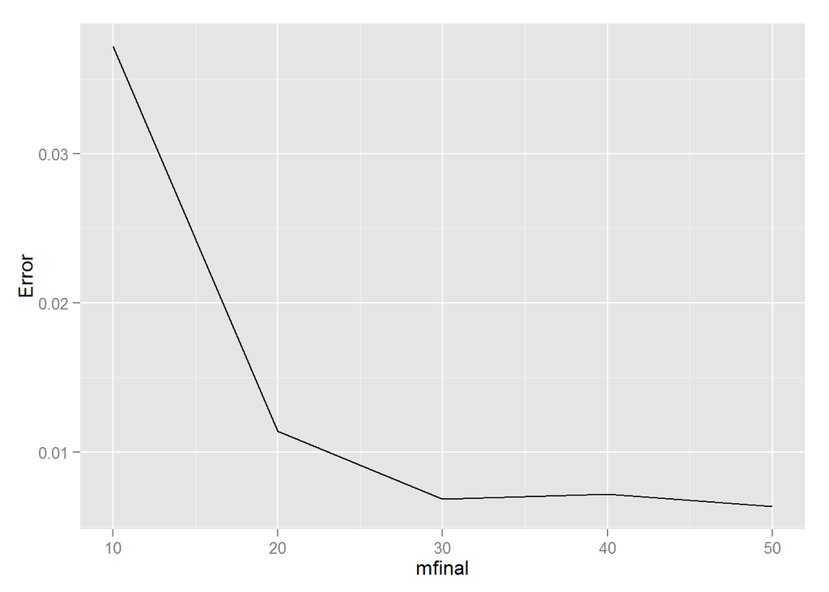

```r
qplot(1:5*10, err, geom = "line", xlab = "mfinal", ylab = "Error")
```

This plot is the cv-error of `mfinal=10,20,30,40,50`. We can say the cv-error hits lowest point after `mfinal=30`.

### Training

We choose `mfinal=30` to train 80% of data. Then use the model to predict 20% of data (`test.set`).

```r
set.seed(1234)
fit <- boosting(classe ~ ., train.set[,-exclude], mfinal = 30)
pred <- predict.boosting(fit, newdata=test.set)
confusion <- confusionMatrix(pred$class, test.set$classe)
```

```r
confusion
```

```
## Confusion Matrix and Statistics
##
##           Reference
## Prediction    A    B    C    D    E
##          A 1116    2    1    0    0
##          B    0  750    1    1    0
##          C    0    5  681    3    0
##          D    0    2    1  637    1
##          E    0    0    0    2  720
##
## Overall Statistics
##
##                Accuracy : 0.9952
##                  95% CI : (0.9924, 0.9971)
##     No Information Rate : 0.2845
##     P-Value [Acc > NIR] : < 2.2e-16
##
##                   Kappa : 0.9939
##  Mcnemar's Test P-Value : NA
##
## Statistics by Class:
##
##                      Class: A Class: B Class: C Class: D Class: E
## Sensitivity            1.0000   0.9881   0.9956   0.9907   0.9986
## Specificity            0.9989   0.9994   0.9975   0.9988   0.9994
## Pos Pred Value         0.9973   0.9973   0.9884   0.9938   0.9972
## Neg Pred Value         1.0000   0.9972   0.9991   0.9982   0.9997
## Prevalence             0.2845   0.1935   0.1744   0.1639   0.1838
## Detection Rate         0.2845   0.1912   0.1736   0.1624   0.1835
## Detection Prevalence   0.2852   0.1917   0.1756   0.1634   0.1840
## Balanced Accuracy      0.9995   0.9938   0.9966   0.9947   0.9990
```

Because `test.set` and `train.set` are independent data sets, the error on `test.set` should be near out of sample error. We expect the out of sample error is 0.0048432 and the 95% confidence-interval is (0.0029184, 0.007553).

## Final Test

We use the mode to predict `finalTest` data set from `pml-testing.csv`. After submitting the answers, all answers are correct from online-judging.

```r
answers <- predict.boosting(fit, finalTest)$class
answers
```

```
##  [1] "B" "A" "B" "A" "A" "E" "D" "B" "A" "A" "B" "C" "B" "A" "E" "E" "A"
## [18] "B" "B" "B"
```